# TP Écomic !

Samuel Barreto

2017-03-01

# Introduction

Dans ce café on va reprendre la plupart des outils qu’on a utilisé jusqu’à maintenant, pour être sûr que ça soit bien rentré dans vos petites têtes de thésards en blouse.

On va d’abord importer les données que les étudiants de mon groupe de TP d’Écologie Microbienne ont produites. Dans ces TP, on exposait des microalgues pendant deux semaines à un herbicide de contact agissant sur la photosynthèse, et on mesurait à J0, J7 et J14 les concentrations cellulaires et la production de pigments par une extraction à l’acétone et des mesures d’absorbance.

L’idée de ce café c’est d’importer les données, de les mettre dans une forme qui convienne bien à nos analyses, et de produire des jolis graphiques comme on sait désormais plutôt bien le faire.

Le bonus de tout ça c’est qu’on va le faire dans un joli rapport `.Rmd` que vous pourrez commenter à loisir et qui vous permettra de comprendre les commandes que vous tapez. Ce qui est chouette.

```r
# importation des packages
library(tidyverse) # pour manipuler les données
library(hrbrthemes) # pour faire des jolis graphiques par défault
library(scales) # pour changer les échelles des graphiques
library(forcats) # pour ajuster les niveaux de facteurs
theme_set(theme_ipsum_rc()) # change le thème par défault
```

## Mesures De Croissance

Toutes les semaines à partir du J0, les étudiants dénombrait *Chlorella*, une microalgue verte et *Phæodactylum*, une microalgue brune à la cellule de Thomas, et on mutualisait les résultats. Les *Pseudomonas* étaient dénombrées par étalement.

Le jeu de donnée est disponible [là](https://figshare.com/articles/cafe_ecomic/4706491), mais on va directement le télécharger via `R`, parce que c’est mieux.

```r
# adresse de destination du fichier qu'on va télécharger.
chlortoluron_file <- "../data-raw/chlortoluron.xlsx"

# si le fichier n'existe PAS (l'importance du symbole ! devant file.exists)
if (!file.exists(chlortoluron_file)) {
  # télécharge le à l'adresse `url`
  download.file(url = "https://ndownloader.figshare.com/files/7684090",
                # enregistre le dans le fichier `destfile`
                destfile = chlortoluron_file)
}

# lit les données avec le package readxl
chlortoluron <- readxl::read_excel(chlortoluron_file)

# jette un œil aux données :
chlortoluron
```

| jour | condition | herbicide | concentration_cellulaire |
| --- | --- | --- | --- |
| 0 | c | 0 | 7250000 |
| 0 | p | 0 | 4000000 |
| 0 | c_cp | 0 | 4380000 |
| 0 | p_cp | 0 | 1800000 |
| 0 | c_cpb | 0 | NA |
| 0 | p_cpb | 0 | NA |
| 0 | b | 0 | 100000 |
| 0 | b_cpb | 0 | 266000 |
| 0 | c | 1 | 6700000 |
| 0 | p | 1 | 2800000 |

[output cut: 38 more lines]

Ici on voit uniquement le résultat des différentes modifications, mais il y a un processus itératif derrière tout ça qui fait qu’on arrive au graphique final produit.

Pendant le café fait ça étape par étape, ici on a juste le résultat final.

```r
condition_levels = c("Bactéries", "Bactéries + CP", "Chlorella",
                     "Chlorella + Phæodactylum",
                     "Chlorella + Phæodactylum + Bactéries", "Phæodactylum",
                     "Phæodactylum + Chlorella",
                     "Phæodactylum + Chlorella + Bactéries")
```

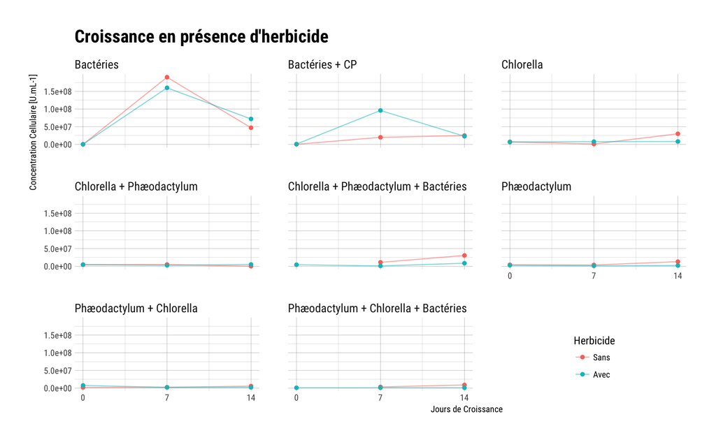

```r
chlortoluron %>%
  # change les niveaux de facteurs (permet de changer l'ordre d'apparition des
  # paneaux dans le graphique)
  mutate(condition = factor(condition, labels = condition_levels)) %>%
  # représente la concentration cellulaire en fonction des jours
  ggplot(aes(x = jour, y = concentration_cellulaire)) +
  # avec des points, et utilise la couleur des points pour représenter la
  # condition avec ou sans herbicide
  geom_point(aes(color = factor(herbicide))) +
  # pareil avec les lignes, et crée une ligne par condition (group = )
  # représente des lignes transparentes à 1/2
  geom_line(aes(group = herbicide, color = factor(herbicide)), alpha = 5/10) +
  # représente un panneau par condition (par mélange algal)
  facet_wrap( ~ condition) +
  # les barreaux de l'échelle en x sont 0 7 et 14
  scale_x_continuous(breaks = c(0, 7, 14)) +
  # l'échelle de couleur n'a pas les bonnes étiquettes par déafaut,
  # et on peut changer son titre.
  scale_color_discrete(labels = c("Sans", "Avec")) +
  # l'échelle en y peut être représentée en notation scientifique
  scale_y_continuous(labels = scientific) +
  # on change les titres des axes, de la légende et du graphique
  labs(x = "Jours de Croissance",
       y = "Concentration Cellulaire [U.mL-1]",
       title = "Croissance en présence d'herbicide",
       color = "Herbicide") +
  # ajuste la position du titre de l'axe x
  theme(axis.title.x = element_text(hjust = 0.66),
        # ajuste la position de la légende, x = 0.85/1 et y = 0.1/1
        legend.position = c(0.85, 0.1))
```

## Mesures de Production de Pigments

On a également mesuré la production de pigment par les mêmes algues, seules, mélangées et mélangées avec *Pseudomonas*.

Donc même topo, on va le télécharger si ça n’est pas déjà fait et le lire dans R.

```r
pigment_file <- "../data-raw/pigments.xls"

if (!file.exists(pigment_file)) {
  download.file(url = "https://ndownloader.figshare.com/files/7684087",
                destfile = pigment_file)
}

pigments <- readxl::read_excel(
  path = pigment_file,
  # les données sont dans la feuille 2 du tableau excel
  sheet = 2,
  # et pour une raison bien inconnue la première ligne est vide.
  skip = 1
)
```

[output not shown]

Il y a des lignes en trop :

```r
tail(pigments)
```

| Modalité | Temps | Algues | vol filtré (l) | vol extrait(ml) | DO 480 | DO 665 | DO 750 | DO 665+HCL | DO 750+HCL | DO' 480 | DO' 665 | DO' 665A | ch.a act(µg/l) | phéo(µg/l) | caro.(µg/l) | Temps | Algues | Modalité |
| --- | --- | --- | --- | --- | --- | --- | --- | --- | --- | --- | --- | --- | --- | --- | --- | --- | --- | --- |
| NA | NA | NA | NA | NA | NA | NA | NA | NA | NA | NA | NA | NA | NA | NA | NA | NA | NA | NA |
| NA | NA | NA | NA | NA | NA | NA | NA | NA | NA | NA | NA | NA | NA | NA | NA | NA | NA | NA |
| NA | NA | NA | NA | NA | NA | NA | NA | NA | NA | NA | NA | NA | NA | NA | NA | NA | NA | NA |
| NA | NA | NA | NA | NA | NA | NA | NA | NA | NA | NA | NA | NA | NA | NA | NA | NA | NA | NA |
| NA | NA | NA | NA | NA | NA | NA | NA | NA | NA | NA | NA | NA | NA | NA | NA | NA | NA | NA |
| NA | NA | NA | NA | NA | NA | NA | NA | NA | NA | NA | NA | NA | NA | NA | NA | NA | NA | NA |

Si on regarde le jeu de données, on voit que seules les 24 premières lignes sont utiles.

Donc on ne garde que ça en utilisant la notation suivante :

```r
pigments <- pigments[1:24,]
pigments
```

| Modalité | Temps | Algues | vol filtré (l) | vol extrait(ml) | DO 480 | DO 665 | DO 750 | DO 665+HCL | DO 750+HCL | DO' 480 | DO' 665 | DO' 665A | ch.a act(µg/l) | phéo(µg/l) | caro.(µg/l) | Temps | Algues | Modalité |
| --- | --- | --- | --- | --- | --- | --- | --- | --- | --- | --- | --- | --- | --- | --- | --- | --- | --- | --- |
| Témoin | J0 | Chlorella | 0.001 | 1.8 | 0.0970 | 0.0960 | 0.0000 | 0.0430 | 0.0020 | 0.0970 | 0.0960 | 0.0410 | 2646 | -1265 | 1746 | J0 | Chlorella | Témoin |
| NA | NA | Phaeodactylum | 0.001 | 1.8 | 0.2070 | 0.2100 | 0.0000 | 0.1380 | 0.0000 | 0.2070 | 0.2100 | 0.1380 | 3464 | 1183 | 3726 | NA | Phaeodactylum | NA |
| NA | NA | C+P | 0.001 | 1.8 | 0.2300 | 0.2080 | 0.0700 | 0.1850 | 0.0385 | 0.1600 | 0.1380 | 0.1465 | -408 | 5343 | -900 | NA | C+P | NA |
| NA | NA | C+P+Bact | 0.001 | 1.8 | 0.3485 | 0.2355 | 0.0490 | 0.1640 | 0.0435 | 0.2995 | 0.1865 | 0.1205 | 3175 | 882 | 2745 | NA | C+P+Bact | NA |
| NA | J7 | Chlorella | 0.001 | 1.8 | 0.3540 | 0.2225 | 0.0440 | 0.1745 | 0.1250 | 0.3100 | 0.1785 | 0.0495 | 6206 | -4539 | 3203 | J7 | Chlorella | NA |
| NA | NA | Phaeodactylum | 0.001 | 1.8 | 0.2630 | 0.1470 | 0.0070 | 0.1210 | 0.0560 | 0.2560 | 0.1400 | 0.0650 | 3608 | -1419 | 4230 | NA | Phaeodactylum | NA |
| NA | NA | C+P | 0.001 | 1.8 | 0.2325 | 0.1340 | 0.0190 | 0.1205 | 0.0350 | 0.2135 | 0.1150 | 0.0855 | 1419 | 1460 | 2817 | NA | C+P | NA |
| NA | NA | C+P+Bact | 0.001 | 1.8 | 0.9080 | 0.5805 | 0.0135 | 0.5680 | 0.1055 | 0.8945 | 0.5670 | 0.4625 | 5027 | 10548 | 15372 | NA | C+P+Bact | NA |
| NA | J14 | Chlorella | 0.001 | 1.8 | 0.9070 | 1.2000 | 0.0680 | 0.7200 | 0.0380 | 0.8390 | 1.1320 | 0.6820 | 21651 | 1318 | 11430 | J14 | Chlorella | NA |
| NA | NA | Phaeodactylum | 0.001 | 1.8 | 0.3540 | 0.4010 | 0.0460 | 0.2305 | 0.0470 | 0.3080 | 0.3550 | 0.1835 | 8251 | -2071 | 3059 | NA | Phaeodactylum | NA |

[output cut: 14 more lines]

Les noms de colonnes sont bien pourris aussi, mais ça on a l’habitude.

```r
pigments <- pigments %>%
  janitor::clean_names()
```

Quelle tête ont les données maintenant ?

```r
pigments
```

| modalité | temps | algues | vol_filtré_l | vol_extrait_ml | do_480 | do_665 | do_750 | do_665_hcl | do_750_hcl | do_480_2 | do_665_2 | do_665a | ch_a_act_µg_l | phéo_µg_l | caro_µg_l | temps_2 | algues_2 | modalité_2 |
| --- | --- | --- | --- | --- | --- | --- | --- | --- | --- | --- | --- | --- | --- | --- | --- | --- | --- | --- |
| Témoin | J0 | Chlorella | 0.001 | 1.8 | 0.0970 | 0.0960 | 0.0000 | 0.0430 | 0.0020 | 0.0970 | 0.0960 | 0.0410 | 2646 | -1265 | 1746 | J0 | Chlorella | Témoin |
| NA | NA | Phaeodactylum | 0.001 | 1.8 | 0.2070 | 0.2100 | 0.0000 | 0.1380 | 0.0000 | 0.2070 | 0.2100 | 0.1380 | 3464 | 1183 | 3726 | NA | Phaeodactylum | NA |
| NA | NA | C+P | 0.001 | 1.8 | 0.2300 | 0.2080 | 0.0700 | 0.1850 | 0.0385 | 0.1600 | 0.1380 | 0.1465 | -408 | 5343 | -900 | NA | C+P | NA |
| NA | NA | C+P+Bact | 0.001 | 1.8 | 0.3485 | 0.2355 | 0.0490 | 0.1640 | 0.0435 | 0.2995 | 0.1865 | 0.1205 | 3175 | 882 | 2745 | NA | C+P+Bact | NA |
| NA | J7 | Chlorella | 0.001 | 1.8 | 0.3540 | 0.2225 | 0.0440 | 0.1745 | 0.1250 | 0.3100 | 0.1785 | 0.0495 | 6206 | -4539 | 3203 | J7 | Chlorella | NA |
| NA | NA | Phaeodactylum | 0.001 | 1.8 | 0.2630 | 0.1470 | 0.0070 | 0.1210 | 0.0560 | 0.2560 | 0.1400 | 0.0650 | 3608 | -1419 | 4230 | NA | Phaeodactylum | NA |
| NA | NA | C+P | 0.001 | 1.8 | 0.2325 | 0.1340 | 0.0190 | 0.1205 | 0.0350 | 0.2135 | 0.1150 | 0.0855 | 1419 | 1460 | 2817 | NA | C+P | NA |
| NA | NA | C+P+Bact | 0.001 | 1.8 | 0.9080 | 0.5805 | 0.0135 | 0.5680 | 0.1055 | 0.8945 | 0.5670 | 0.4625 | 5027 | 10548 | 15372 | NA | C+P+Bact | NA |
| NA | J14 | Chlorella | 0.001 | 1.8 | 0.9070 | 1.2000 | 0.0680 | 0.7200 | 0.0380 | 0.8390 | 1.1320 | 0.6820 | 21651 | 1318 | 11430 | J14 | Chlorella | NA |
| NA | NA | Phaeodactylum | 0.001 | 1.8 | 0.3540 | 0.4010 | 0.0460 | 0.2305 | 0.0470 | 0.3080 | 0.3550 | 0.1835 | 8251 | -2071 | 3059 | NA | Phaeodactylum | NA |

[output cut: 14 more lines]

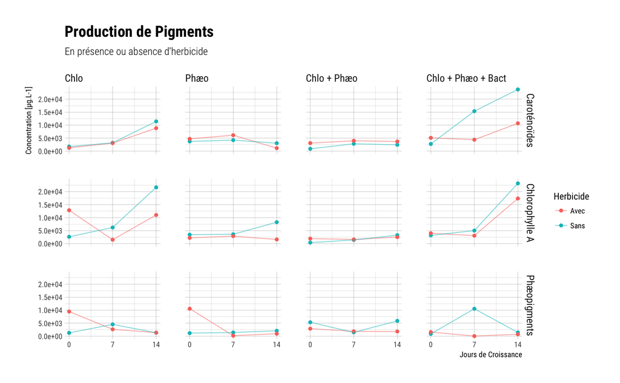

```r
pigments %>%
  # change la colonne modalité
  mutate(modalité = c(rep("Témoin", 12), rep("Herbicide", 12)),
         # change la colonne temps
         temps = rep(c(0, 7, 14), 4) %>% sort() %>% rep(2)) %>%
  # ne garde que les colonnes qui nous intéressent. `contains` est bien pratique
  # et permet de ne garder que les colonnes qui contiennent un µg_l dans leur nom
  select(modalité, temps, algues, contains("µg_l")) %>%
  # on remodèle le tableau pour qu'il ait la bonne forme
  gather(pigment, concentration, -modalité, -temps, -algues) %>%
  # et on change certaines colonnes
  mutate(
    concentration =
      # convertit concentration en nombres
      as.numeric(concentration)
   ,algues =
      # change les niveaux de facteurs dans la colonne algues
      factor(algues
             # les niveaux sont les suivants
            ,levels = c("Chlorella", "Phaeodactylum", "C+P", "C+P+Bact")
             # les noms des niveaux sont les suivants.
             # (on peut nommer les barreaux d'une échelle dans R)
            ,labels = c("Chlo", "Phæo", "Chlo + Phæo", "Chlo + Phæo + Bact"))
   ,pigment =
      factor(pigment
             # on fait pareil, on change les noms des niveaux de facteurs.
            ,labels = c("Caroténoïdes", "Chlorophylle A", "Phæopigments"))
   ,concentration =
      # rend les valeurs négatives, positives
      ifelse(concentration < 0, -concentration, concentration)
  ) %>%
  # représente la concentration en fonction du temps
  ggplot(aes(x = temps, y = concentration)) +
  # par des points dont la couleur représente le traitement
  geom_point(aes(color = modalité)) +
  # trace des lignes entre les points par modalité
  geom_line(aes(group = modalité, color = modalité), alpha = 5/10) +
  # représente une grille de panneau par pigment mesuré et par mélange algal
  facet_grid(pigment ~ algues) +
  # change les étiquettes de la dimension couleur
  scale_color_discrete(labels = c("Avec", "Sans")) +
  # change les barreaux de l'échelle en x
  scale_x_continuous(breaks = c(0, 7, 14)) +
  # utilise la notation scientifique sur l'axe y
  scale_y_continuous(labels = scientific) +
  # change les étiquettes des axes et les titres des axes
  labs(x = "Jours de Croissance",
       y = "Concentration [µg.L-1]",
       color = "Herbicide",
       title = "Production de Pigments",
       subtitle = "En présence ou absence d'herbicide")
```